# Evaluación de la dieta en la mortalidad del Salmón del Atlántico

Constanza Pino Ajenjo

2022-07-01

**Introducción**

**1.** **Descripción del problema a resolver:**

Han surgido dietas especiales y funcionales que atacan los principales problemas sanitarios que afectan a los peces, e incluso alternativas que ayudan a los ejemplares a recuperarse tras los blooms de algas en centros de cultivo en agua mar [^1]. Debido a su impacto en la salud de Salmón del Atlántico, es importante evaluar la relación de la dieta en la mortalidad en los centros de cultivo en agua de mar.

- número de ingreso de peces (Ingreso)
- peso promedio de los peces cosechados en kilogramos (Peso_cosecha)
- proporción de la mortalidad (Mortalidad)

**Análisis exploratodio de los datos**

**1.** **Exploración y depuración de los datos**

**1.1** **Balanceo de datos:**

1. Se filtran las dietas con mayor y similar número de n muestreal (BES1 y BS1).
2. Se calcula la proporción (Prop_Mort) entre el número de mortalidad (Mortalidad) con respecto al número de peces ingresados, para usar como variable de estudio.
3. Se explora si las variables son números o carácteres y, luego se transforman las variables Unidad y Dieta en factores.
4. Se identifica que los datos estén balanceados usando una tabla de frecuencia de los datos.

```r
#Cargar la base de datos en el objeto Salar:
Salar <- read_excel("Salar.xlsx", sheet=1,na="NA")
Salar <- na.omit(Salar)
head(Salar)
```

```
## # A tibble: 6 × 6
##   Unidad Dieta Ingreso Peso_cosecha Mortalidad Prop_Mort
##    <dbl> <chr>   <dbl>        <dbl>      <dbl>     <dbl>
## 1      1 BES1    83334          5.3       6748      0.08
## 2      2 BES1    83044          4.9       5850      0.07
## 3      3 BES1    83333          5.3       8116      0.1
## 4      4 BES1    83622          5         4632      0.06
## 5      5 BES1    83334          5.7      12765      0.15
## 6      6 BES1    83150          5.2      10187      0.12
```

```r
#Explorar si las variables son números o carácteres:
str(Salar)
```

```
## tibble [137 × 6] (S3: tbl_df/tbl/data.frame)
##  $ Unidad      : num [1:137] 1 2 3 4 5 6 7 8 9 10 ...
##  $ Dieta       : chr [1:137] "BES1" "BES1" "BES1" "BES1" ...
##  $ Ingreso     : num [1:137] 83334 83044 83333 83622 83334 ...
##  $ Peso_cosecha: num [1:137] 5.3 4.9 5.3 5 5.7 5.2 4.6 5.3 5.4 5.4 ...
##  $ Mortalidad  : num [1:137] 6748 5850 8116 4632 12765 ...
##  $ Prop_Mort   : num [1:137] 0.08 0.07 0.1 0.06 0.15 0.12 0.09 0.1 0.09 0.11 ...
##  - attr(*, "na.action")= 'omit' Named int [1:44] 128 129 130 131 132 133 134 135 136 137 ...
##   ..- attr(*, "names")= chr [1:44] "128" "129" "130" "131" ...
```

```r
#Transformar Unidad y Dieta a factor usando as.factor, luego visualizar que Unidad y Dieta estén transformados adecuadamente a factor y que los datos están balanceados:
Salar$Unidad <- as.factor(Salar$Unidad)
Salar$Dieta <- as.factor(Salar$Dieta)
summary(Salar)
```

```
##      Unidad     Dieta       Ingreso        Peso_cosecha     Mortalidad
##  1      :  1   BES1:71   Min.   : 59711   Min.   :3.700   Min.   : 4632
##  2      :  1   BS1 :66   1st Qu.: 80578   1st Qu.:4.800   1st Qu.: 9680
##  3      :  1             Median : 87500   Median :5.200   Median :15321
##  4      :  1             Mean   : 86910   Mean   :5.201   Mean   :17086
##  5      :  1             3rd Qu.: 96275   3rd Qu.:5.600   3rd Qu.:21041
##  6      :  1             Max.   :105438   Max.   :6.300   Max.   :48484
##  (Other):131
##    Prop_Mort
##  Min.   :0.0600
##  1st Qu.:0.1100
##  Median :0.1800
##  Mean   :0.1977
##  3rd Qu.:0.2500
##  Max.   :0.4900
##
```

**1.2.** **Tablas de resumen:**

En la Tabla 1 se muestra la base de datos que se utiliza en este trabajo y, luego, en la Tabla 2 está un resumen de estadística descriptiva.

```r
#Generar una tabla con la base de datos de Dieta con función datatable:
DT::datatable(Salar,caption="Tabla 1. Base de datos")
```

|  | Unidad | Dieta | Ingreso | Peso_cosecha | Mortalidad | Prop_Mort |
| --- | --- | --- | --- | --- | --- | --- |
| 1 | 1 | BES1 | 83334 | 5.3 | 6748 | 0.08 |
| 2 | 2 | BES1 | 83044 | 4.9 | 5850 | 0.07 |
| 3 | 3 | BES1 | 83333 | 5.3 | 8116 | 0.1 |
| 4 | 4 | BES1 | 83622 | 5 | 4632 | 0.06 |
| 5 | 5 | BES1 | 83334 | 5.7 | 12765 | 0.15 |
| 6 | 6 | BES1 | 83150 | 5.2 | 10187 | 0.12 |
| 7 | 7 | BES1 | 83333 | 4.6 | 7896 | 0.09 |
| 8 | 8 | BES1 | 83516 | 5.3 | 8721 | 0.1 |
| 9 | 9 | BES1 | 83334 | 5.4 | 7434 | 0.09 |
| 10 | 10 | BES1 | 82300 | 5.4 | 8876 | 0.11 |

[output cut: 127 more lines]

```r
#Resumen de estadística descriptiva con función pander:
pander(summary(Salar,caption="Tabla 2. Resumen data frame"))
```

Table continues below

| Unidad | Dieta | Ingreso | Peso_cosecha | Mortalidad |
| --- | --- | --- | --- | --- |
| 1 : 1 | BES1:71 | Min. : 59711 | Min. :3.700 | Min. : 4632 |
| 2 : 1 | BS1 :66 | 1st Qu.: 80578 | 1st Qu.:4.800 | 1st Qu.: 9680 |
| 3 : 1 | NA | Median : 87500 | Median :5.200 | Median :15321 |
| 4 : 1 | NA | Mean : 86910 | Mean :5.201 | Mean :17086 |
| 5 : 1 | NA | 3rd Qu.: 96275 | 3rd Qu.:5.600 | 3rd Qu.:21041 |
| 6 : 1 | NA | Max. :105438 | Max. :6.300 | Max. :48484 |
| (Other):131 | NA | NA | NA | NA |

| Prop_Mort |
| --- |
| Min. :0.0600 |
| 1st Qu.:0.1100 |
| Median :0.1800 |
| Mean :0.1977 |
| 3rd Qu.:0.2500 |
| Max. :0.4900 |
| NA |

**1.3.** **Gráficos de histogramas y boxplot:**

Se describe la variación de cada variable de estudio usando histogramas y boxplot. En la Figura 1 se muestran los histogramas de ingreso, peso de cosecha promedio (kg) y porporción de la mortalidad. Mientras que en la Figura 2 y 3 se muestran los boxplot de las mismas variables por Unidad y Dieta respectivamente.

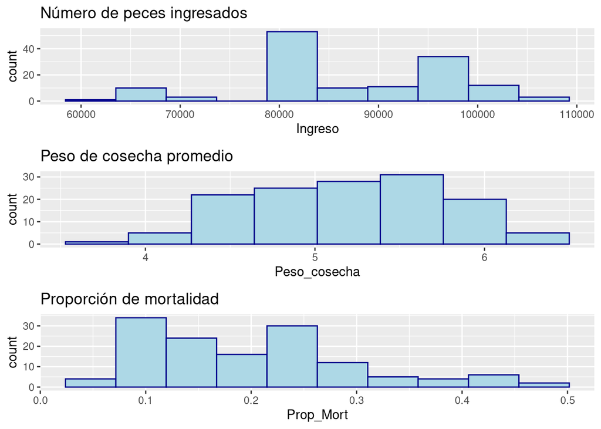

```r
#Observar el comportamiento de las variables en estudio usando histogramas y boxplot (valor atípico se muestra en punto de color rojo):

hist_ing <- ggplot(Salar,aes(Ingreso))+
  geom_histogram(fill="lightblue",color="darkblue",bins=10)+
  labs(title = "Número de peces ingresados")

hist_peso <- ggplot(Salar,aes(Peso_cosecha))+
  geom_histogram(fill="lightblue",color="darkblue",bins=8)+
  labs(title = "Peso de cosecha promedio")

hist_mort <- ggplot(Salar,aes(Prop_Mort))+
  geom_histogram(fill="lightblue",color="darkblue",bins=10)+
  labs(title = "Proporción de mortalidad")

grid.arrange(hist_ing, hist_peso, hist_mort, ncol=1, nrow =3)
```

Figura 1. En esta figura se observa que el histograma de número de peces ingresado no tiene una distribución normal, el histograma de peso de cosecha promedio tiene una distribución hacia la izquierda y el histograma de proporción de la mortalidad tiene una distribución hacia la derecha.

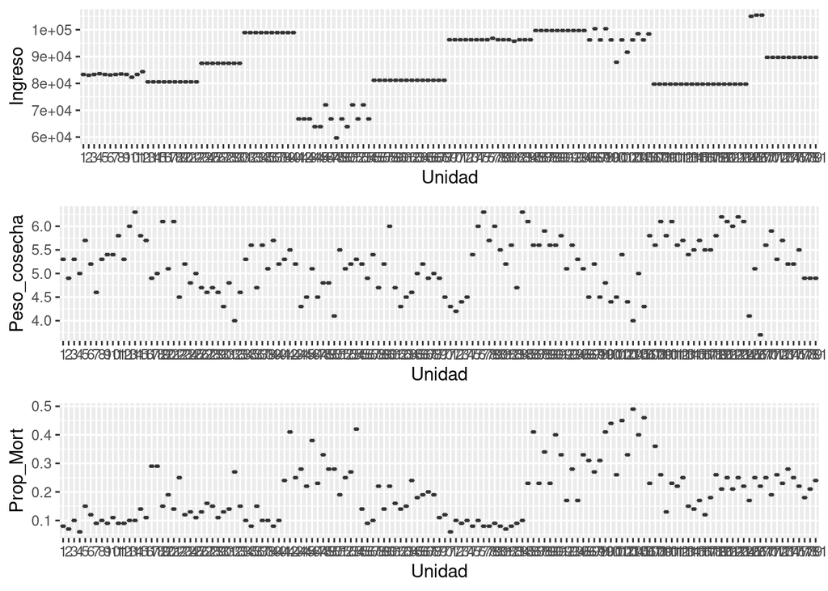

```r
bi <-ggplot(data=Salar, aes(x=Unidad,y=Ingreso))+geom_boxplot()
bp <-ggplot(data=Salar, aes(x=Unidad,y=Peso_cosecha))+geom_boxplot()
bm <-ggplot(data=Salar, aes(x=Unidad,y=Prop_Mort))+geom_boxplot()

grid.arrange(bi, bp, bm, ncol=1, nrow =3)
```

Figura 2. Se observa que el número de peces ingresados por jaula son distintos por Centro de agua de mar, mientras que gran parte del peso de cosecha promedio está en un rango entre 4 y 6 kg. En cuanto a la proporción de la mortalidad se encuentra en un rango entre 5% y 50%.

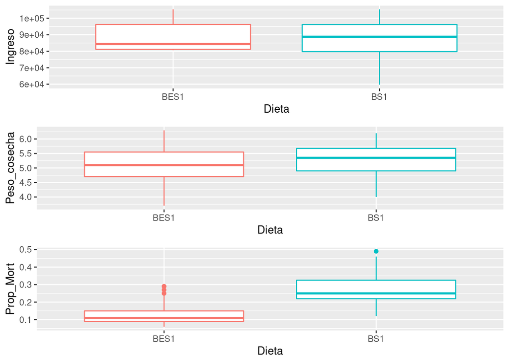

```r
blot_ing <- ggplot(Salar,aes(y=Ingreso,x=Dieta, color=Dieta))+
  geom_boxplot()+theme(legend.position="none")

blot_peso <- ggplot(Salar,aes(y=Peso_cosecha,x=Dieta, color=Dieta))+
  geom_boxplot()+theme(legend.position="none")

blot_mort <- ggplot(Salar,aes(y=Prop_Mort,x=Dieta, color=Dieta))+
  geom_boxplot()+theme(legend.position="none")

grid.arrange(blot_ing, blot_peso, blot_mort, ncol=1, nrow =3)
```

**1.4.** **Gráficos de interacción entre variables y factores:**

En las siguiente Figura 4 se muestran los gráficos de interacción entre cada variable cuantitativa y los factores Unidad y Dieta.

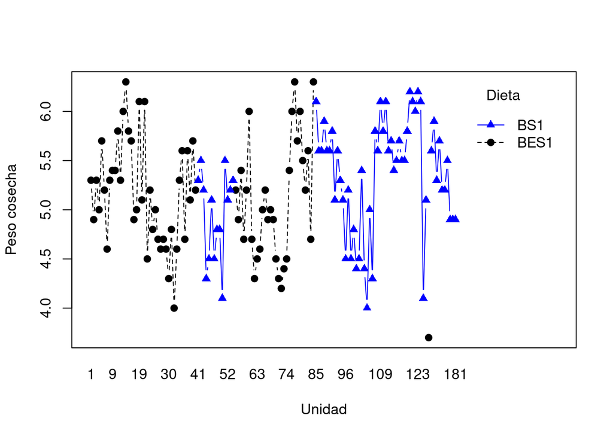

```r
#Establecer relación entre variables cuantitativas y factores usando gráficas de correlación, boxplot, interacción o de tamaño de los efectos:

ip1 <- interaction.plot(Salar$Unidad,Salar$Dieta, Salar$Peso_cosecha,trace.label="Dieta",fun=mean, xlab="Unidad",ylab="Peso cosecha",type="b", col= c("black", "blue"),pch=c(19,17))
```

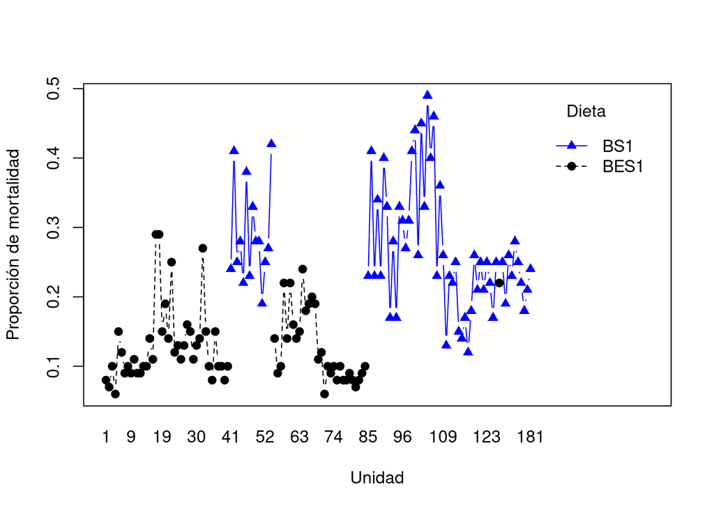

```r
ip2 <- interaction.plot(Salar$Unidad,Salar$Dieta,Salar$Prop_Mort,trace.label="Dieta",fun=mean,xlab="Unidad",ylab="Proporción de mortalidad",type="b", col= c("black", "blue"),pch=c(19,17))
```

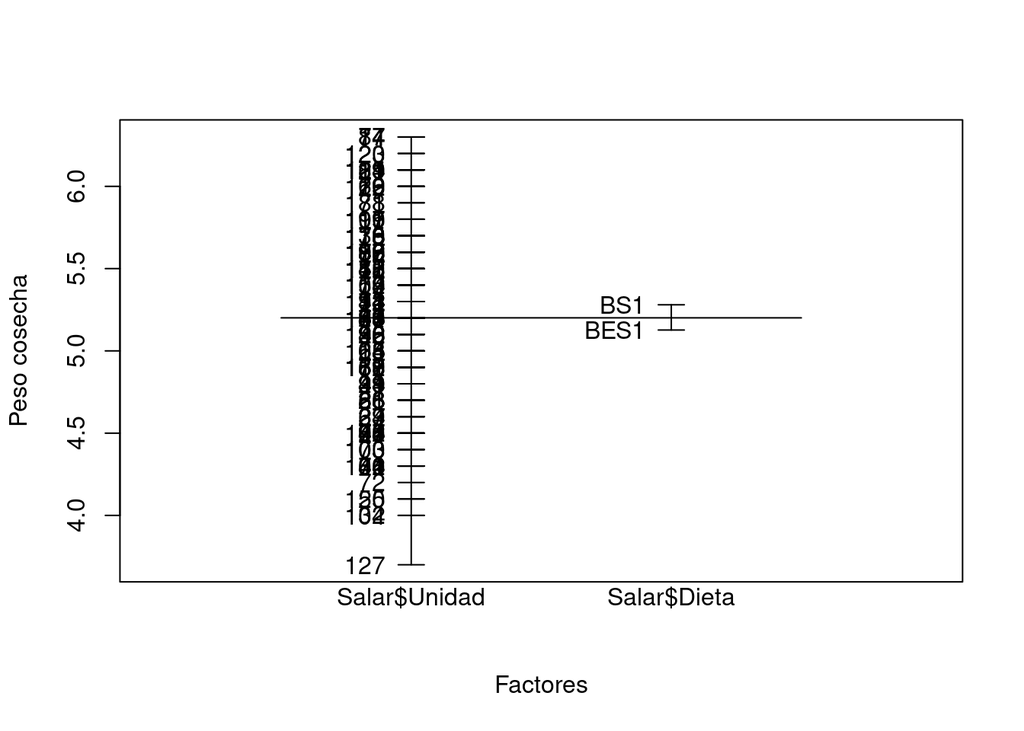

```r
id1 <- plot.design(Salar$Peso_cosecha ~ Salar$Unidad*Salar$Dieta,xlab="Factores", ylab="Peso cosecha")
```

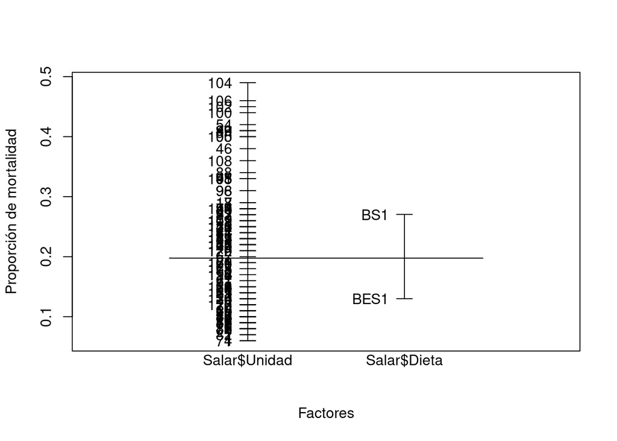

```r
id2 <- plot.design(Salar$Prop_Mort ~ Salar$Unidad*Salar$Dieta,xlab="Factores", ylab="Proporción de mortalidad")
```

**2.** **Evaluación de los supuestos**

Se evalúa si se cumplen los tres supuestos con los siguientes métodos basados en análisis de residuales:

```r
#Anova en la forma de modelo lineal

m1 <- lm(Salar$Prop_Mort ~ Salar$Dieta)
anova(m1) %>% kable(digits = 3)
```

|  | Df | Sum Sq | Mean Sq | F value | Pr(>F) |
| --- | --- | --- | --- | --- | --- |
| Salar$Dieta | 1 | 0.675 | 0.675 | 131.583 | 0 |
| Residuals | 135 | 0.692 | 0.005 | NA | NA |

**1) Independencia:** se evalúa con gráfico de residuales y test de Durbin-Watson

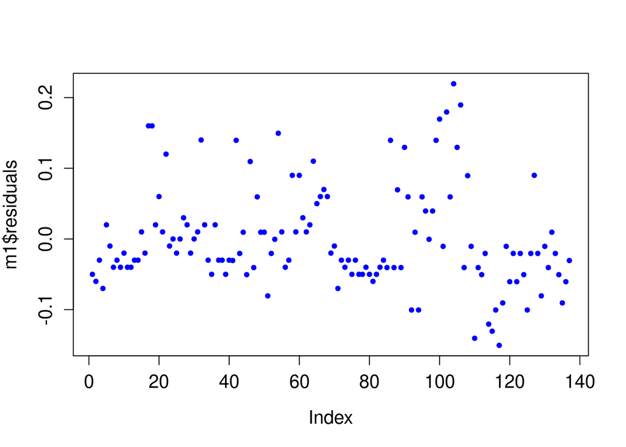

```r
plot(m1$residuals, pch=20, col = "blue",
cex.lab=1.25, cex.axis=1.25)
```

```r
#H0: Son independientes o no existe autocorrelación.
#HA: No son independientes y existe autocorrelación.

dwtest(Prop_Mort ~ Dieta, data = Salar,
alternative = c("two.sided"),
iterations = 15)
```

```
##
##  Durbin-Watson test
##
## data:  Prop_Mort ~ Dieta
## DW = 1.3054, p-value = 2.945e-05
## alternative hypothesis: true autocorrelation is not 0
```

**2) Homocedasticidad:** se usa gráfico de residuales vesus ajustado de un modelo lineal y Prueba de Levene.

Figura 6. En el gráfico de Residuals vs Fitted se evalúa la homocedasticidad, donde la línea roja muestra el promedio de los valores. En este gráfico, se observa aumento de los valores ajustados hacia la derecha mientras aumenta la dispersión de los residuales indicando que no hay homocedasticidad.

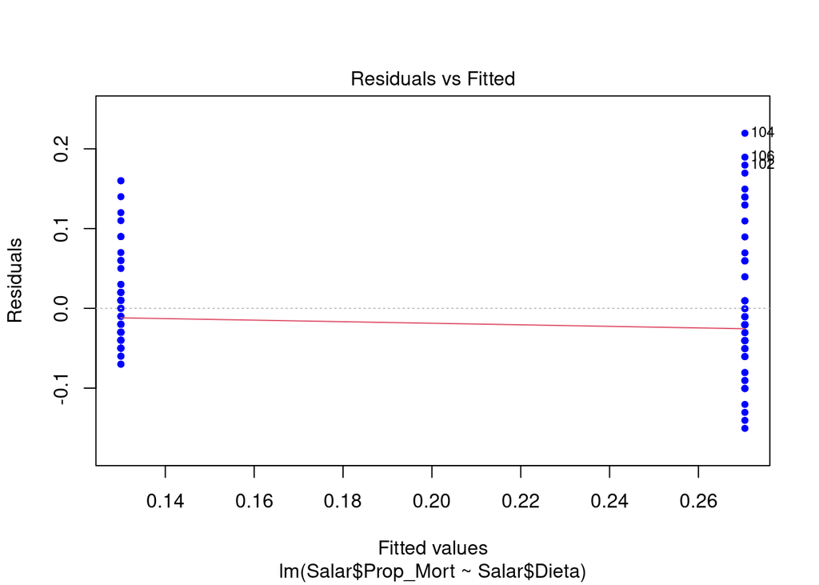

```r
plot(m1, 1, pch=20, col = "blue")
```

```r
lv <- leveneTest(Prop_Mort ~ Dieta, data = Salar,
           center = "median")

lv %>% kable(digits = 3, caption = "Homogenecidad con Prueba de Levene")
```

Homogenecidad con Prueba de Levene

|  | Df | F value | Pr(>F) |
| --- | --- | --- | --- |
| group | 1 | 7.371 | 0.007 |
|  | 135 | NA | NA |

**3) Normalidad:** se evalúa con análisis de residuales de un lineal general.

Figura 7. En el gráfico de abajo se determina si se cumple el supuesto de normalidad. La línea diagonal de color azul indica los cuantiles teóricos en la distribución normal. En este segundo gráfico se observa que la distribución de los residuos se desvía de la distribución normal teórica, debido a que los residuos se apartan de la diagonal.

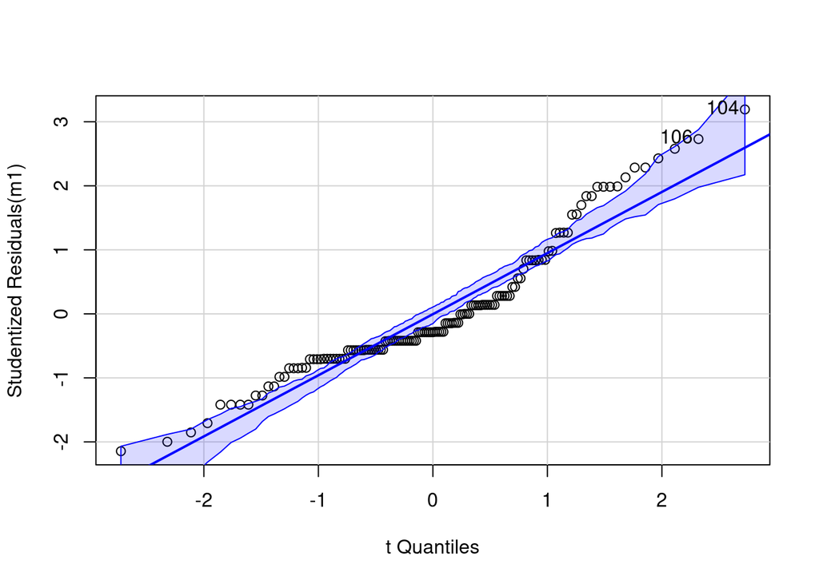

```
## [1] 104 106
```

```r
qqPlot(m1)
```

**3.** **Hipótesis:**

- Hipótesis nula (H0): la dieta no tiene relación con la proporción de la mortalidad del Salmón del Atlántico.
- Hipotesis alternativa (H1): la dieta si tiene relación con la proporción de la mortalidad.

**4.** **Prueba de hipótesis**

Se genera un modelo lineal generalizado Binomial junto con anova del modelo. El p-value del modelo logit en las dos dietas (BS1 y BES1) es menor a 0,05 (95% de confianza), por lo tanto se rechaza la hipotesis nula (H0). Sin embargo, al comparar los valores AIC entre modelo nulo y modelo logit, el modelo nulo tiene menor valor que el modelo logit, o sea, el modelo nulo es mejor este que el modelo logit.

```r
#Modelo lineal generalizado con Binomial:

mod_nulo <- glm(Prop_Mort ~ 1, family=binomial, data = Salar)
summary(mod_nulo)$coef %>% kable()
```

|  | Estimate | Std. Error | z value | Pr(>\|z\|) |
| --- | --- | --- | --- | --- |
| (Intercept) | -1.400957 | 0.2145345 | -6.53022 | 0 |

```r
mod_logit <- glm(Prop_Mort ~ Dieta, family=binomial, data = Salar)
summary(mod_logit)$coef %>% kable()
```

|  | Estimate | Std. Error | z value | Pr(>\|z\|) |
| --- | --- | --- | --- | --- |
| (Intercept) | -1.9009588 | 0.3528901 | -5.386829 | 0.0000001 |
| DietaBS1 | 0.9086411 | 0.4486895 | 2.025100 | 0.0428571 |

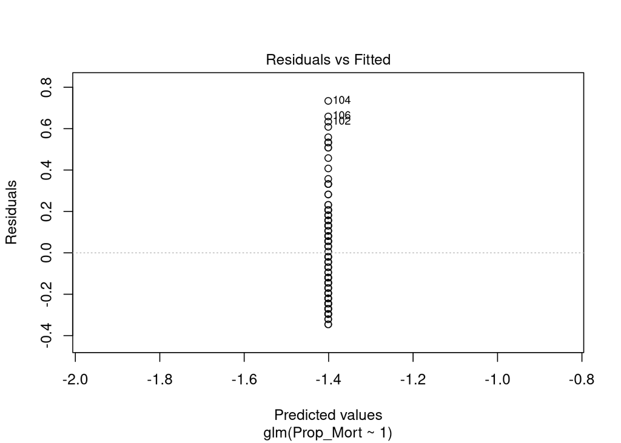

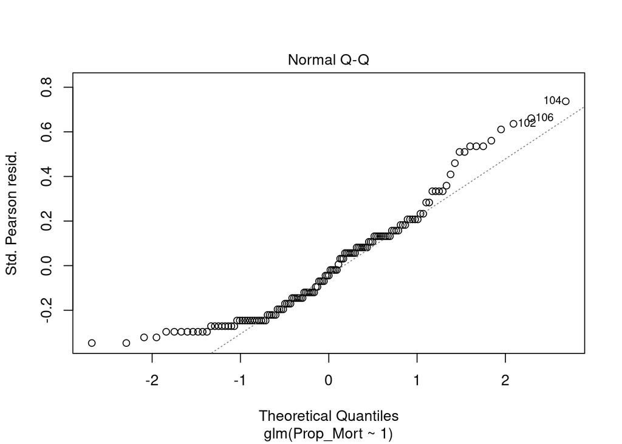

```
## hat values (leverages) are all = 0.00729927
##  and there are no factor predictors; no plot no. 5
```

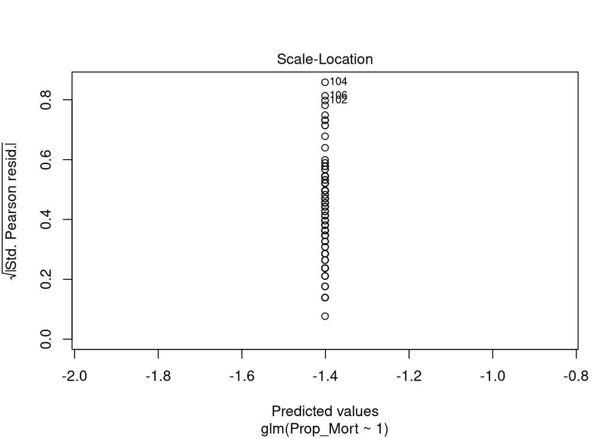

```r
plot(mod_nulo)
```

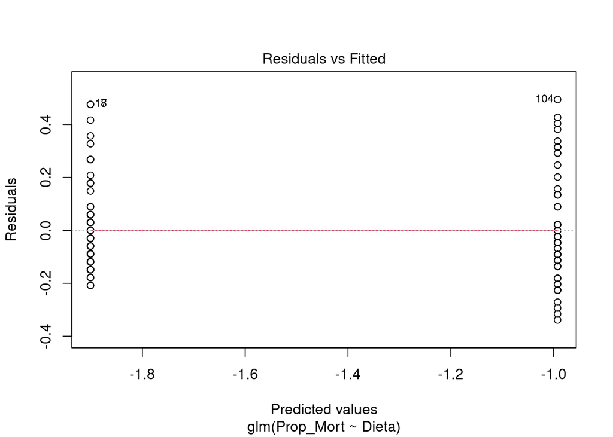

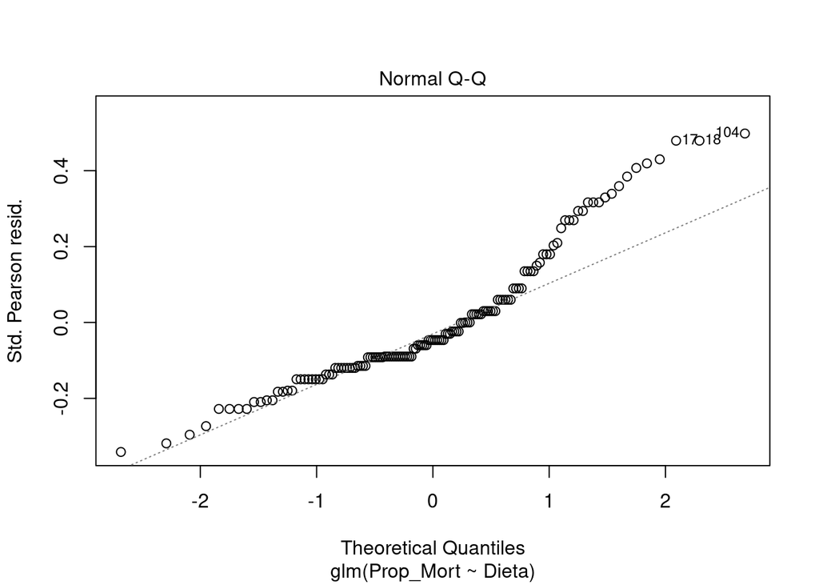

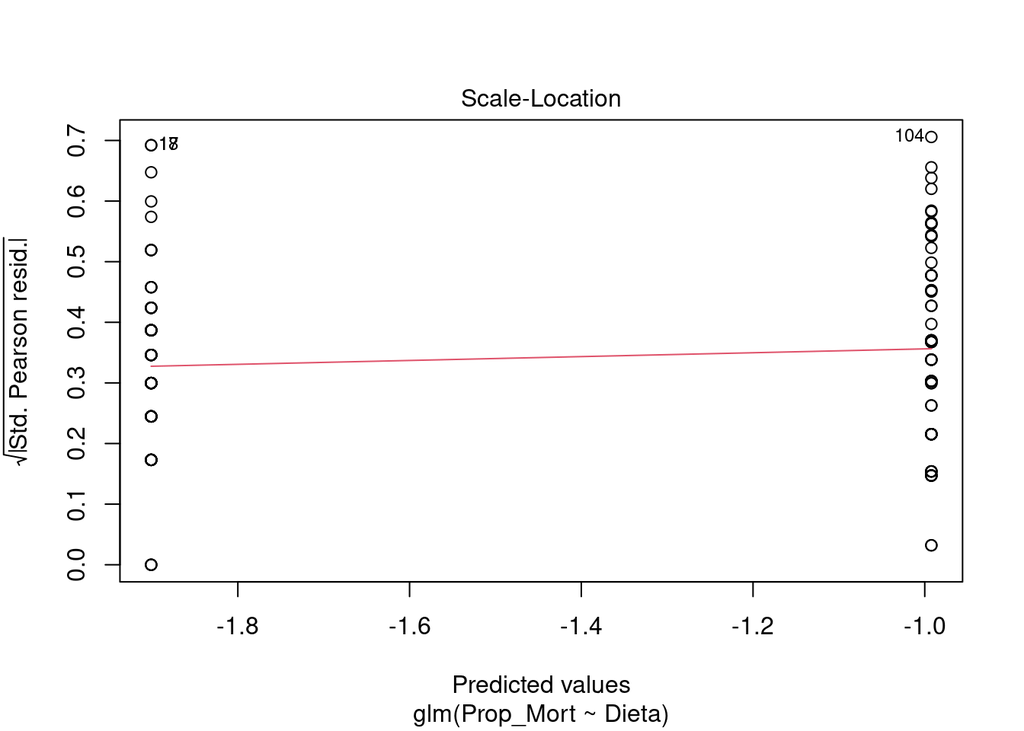

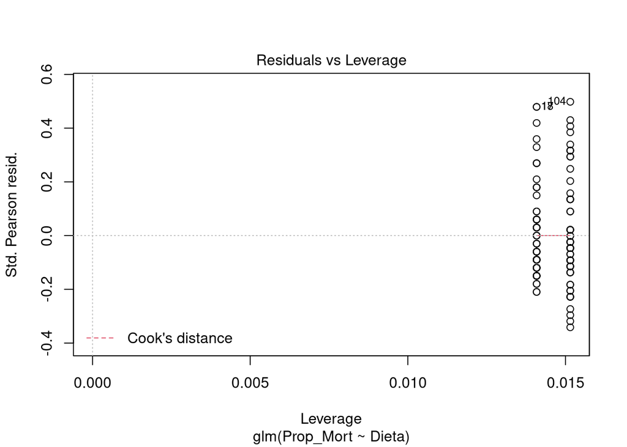

```r
plot(mod_logit)
```

```r
AIC(mod_nulo,mod_logit)
```

```
##           df      AIC
## mod_nulo   1 62.34250
## mod_logit  2 65.39925
```

```r
BIC(mod_nulo,mod_logit)
```

```
##           df      BIC
## mod_nulo   1 65.26248
## mod_logit  2 71.23921
```

```r
anova(mod_logit, test ='Chisq')
```

```
## Analysis of Deviance Table
##
## Model: binomial, link: logit
##
## Response: Prop_Mort
##
## Terms added sequentially (first to last)
##
##
##       Df Deviance Resid. Df Resid. Dev Pr(>Chi)
## NULL                    136     8.4111
## Dieta  1   4.3017       135     4.1094  0.03808 *
## ---
## Signif. codes:  0 '***' 0.001 '**' 0.01 '*' 0.05 '.' 0.1 ' ' 1
```

**4.** **Conclusión principal**

- La hipotesis nula es rechazada, es decir, la dieta está asociada a la proporción de la mortalidad del Salmón del Atlántico.
- Se debe incluir otra u otras variables predictoras además de la dieta, para poder explicar la proporción de la mortalidad.
- A partir de este análisis se puede estudiar cual tipo de dieta tiene mayor relación en la proporción de la mortalidad, creando nuevas hipotésis y sometiendo a otros modelos estadísticos.
[^1]: AQUA. Nutrición: Las súper dietas para el cultivo del salmón. https://www.aqua.cl/reportajes/nutricion-las-super-dietas-cultivo-salmon/